# TCGA pan-cancer analysis

### Linear kernel SVM

The vanilladot kernel applies a simple linear kernel.

```r
library(kernlab)
svm_model <- ksvm(treatments_pharmaceutical_treatment_or_therapy ~ .,
                  data=trainData, kernel="vanilladot")
```

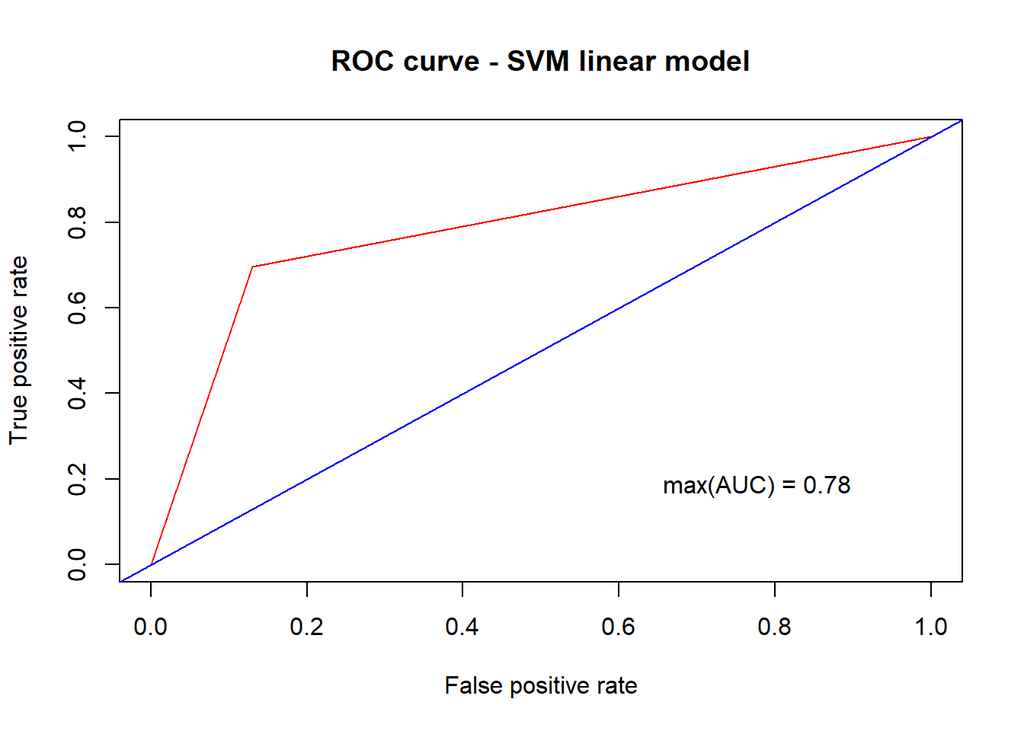

```r
svm_model_predict <- predict(svm_model, testData)


vanilla_prediction <- prediction(as.numeric(svm_model_predict),
                                 as.numeric(test_labels))
perf_vanilla <- ROCR::performance(vanilla_prediction, "tpr", "fpr")

auc <- performance(vanilla_prediction, "auc")
# now converting S4 class to vector
auc <- unlist(slot(auc, "y.values"))
# adding min and max ROC AUC to the center of the plot
maxauc<-max(round(auc, digits = 2))
maxauct <- paste(c("max(AUC) = "),maxauc,sep="")
plot(perf_vanilla, col="red", main="ROC curve - SVM linear model")
line=abline(0,1, col="blue")
legend(0.6,0.3,c(maxauct,"\n"),border="white",cex=1.0,box.col = "white")
```

```r
confusionMatrix(test_labels, svm_model_predict,
                dnn = c('Test Data', 'Predicted'))
```

```
## Confusion Matrix and Statistics
##
##          Predicted
## Test Data   no  yes
##       no  1155  172
##       yes  296  679
##
##                Accuracy : 0.7967
##                  95% CI : (0.7797, 0.813)
##     No Information Rate : 0.6303
##     P-Value [Acc > NIR] : < 2.2e-16
##
##                   Kappa : 0.5765
##
##  Mcnemar's Test P-Value : 1.303e-08
##
##             Sensitivity : 0.7960
##             Specificity : 0.7979
##          Pos Pred Value : 0.8704
##          Neg Pred Value : 0.6964
##              Prevalence : 0.6303
##          Detection Rate : 0.5017
##    Detection Prevalence : 0.5765
##       Balanced Accuracy : 0.7969
##
##        'Positive' Class : no
##
```

### Gaussian Radial basis function kernel SVM

The rbfdot kernel is the standard Gaussian Radial basis function:

```r
svm_model <- ksvm(treatments_pharmaceutical_treatment_or_therapy ~ .,
                  data=trainData, kernel="rbfdot")
```

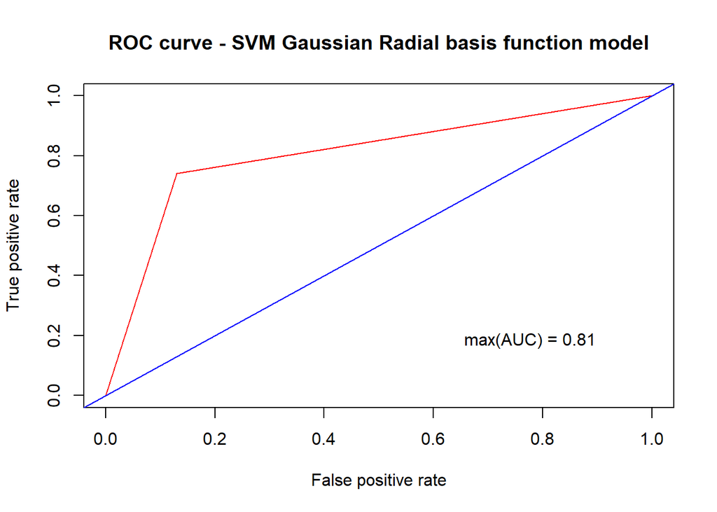

```r
svm_model_predict <- predict(svm_model, testData)

rbf_prediction <- prediction(as.numeric(svm_model_predict),
                             as.numeric(test_labels))
perf_rbf <- ROCR::performance(rbf_prediction, "tpr", "fpr")

auc <- performance(rbf_prediction, "auc")
# now converting S4 class to vector
auc <- unlist(slot(auc, "y.values"))
# adding min and max ROC AUC to the center of the plot
maxauc<-max(round(auc, digits = 2))
maxauct <- paste(c("max(AUC) = "),maxauc,sep="")
plot(perf_rbf, col="red",
     main="ROC curve - SVM Gaussian Radial basis function model")
line=abline(0,1, col="blue")
legend(0.6,0.3,c(maxauct,"\n"),border="white",cex=1.0,box.col = "white")
```

```r
confusionMatrix(test_labels, svm_model_predict,
                dnn = c('Test Data', 'Predicted'))
```

```
## Confusion Matrix and Statistics
##
##          Predicted
## Test Data   no  yes
##       no  1154  173
##       yes  253  722
##
##                Accuracy : 0.8149
##                  95% CI : (0.7985, 0.8306)
##     No Information Rate : 0.6112
##     P-Value [Acc > NIR] : < 2.2e-16
##
##                   Kappa : 0.6169
##
##  Mcnemar's Test P-Value : 0.0001294
##
##             Sensitivity : 0.8202
##             Specificity : 0.8067
##          Pos Pred Value : 0.8696
##          Neg Pred Value : 0.7405
##              Prevalence : 0.6112
##          Detection Rate : 0.5013
##    Detection Prevalence : 0.5765
##       Balanced Accuracy : 0.8134
##
##        'Positive' Class : no
##
```

This outcome is much better- around 82%.

### Polynomial kernel SVM

Polydot is the simple polynomial kernel.

```r
svm_model <- ksvm(treatments_pharmaceutical_treatment_or_therapy ~ .,
                  data=trainData, kernel="polydot")
```

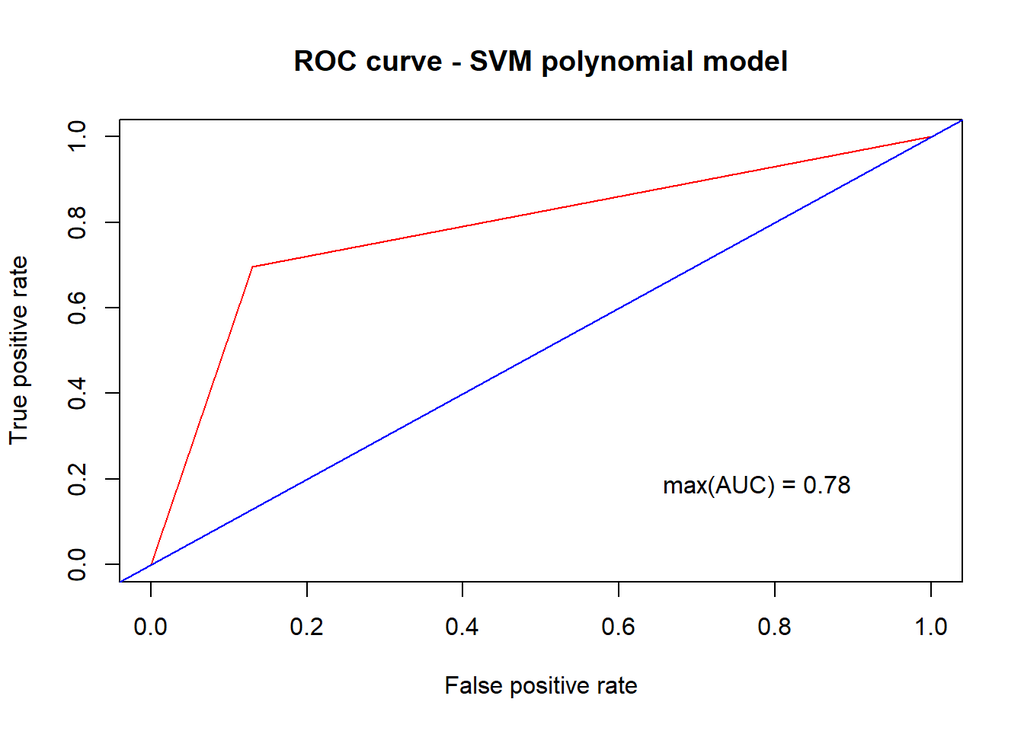

```r
svm_model_predict <- predict(svm_model, testData)

poly_prediction <- prediction(as.numeric(svm_model_predict),
                              as.numeric(test_labels))
perf_poly <- ROCR::performance(poly_prediction, "tpr", "fpr")

auc <- performance(poly_prediction, "auc")
# now converting S4 class to vector
auc <- unlist(slot(auc, "y.values"))
# adding min and max ROC AUC to the center of the plot
maxauc<-max(round(auc, digits = 2))
maxauct <- paste(c("max(AUC) = "),maxauc,sep="")
plot(perf_poly, col="red", main="ROC curve - SVM polynomial model")
line=abline(0,1, col="blue")
legend(0.6,0.3,c(maxauct,"\n"),border="white",cex=1.0,box.col = "white")
```

```r
confusionMatrix(test_labels, svm_model_predict,
                dnn = c('Test Data', 'Predicted'))
```

```
## Confusion Matrix and Statistics
##
##          Predicted
## Test Data   no  yes
##       no  1155  172
##       yes  296  679
##
##                Accuracy : 0.7967
##                  95% CI : (0.7797, 0.813)
##     No Information Rate : 0.6303
##     P-Value [Acc > NIR] : < 2.2e-16
##
##                   Kappa : 0.5765
##
##  Mcnemar's Test P-Value : 1.303e-08
##
##             Sensitivity : 0.7960
##             Specificity : 0.7979
##          Pos Pred Value : 0.8704
##          Neg Pred Value : 0.6964
##              Prevalence : 0.6303
##          Detection Rate : 0.5017
##    Detection Prevalence : 0.5765
##       Balanced Accuracy : 0.7969
##
##        'Positive' Class : no
##
```

This outcome is more or less like the vanilla dot.

### K-Means Elbow method

K-Means is a non supervised clustering algorithm. using the **elbow method** i will try to detect the best k:

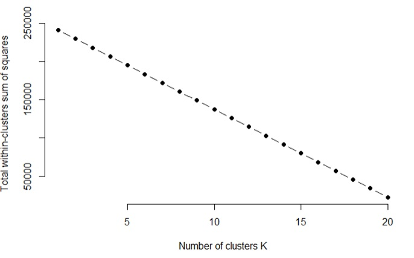

```r
set.seed(123)
library(purrr)
#Elbow Method for finding the optimal number of clusters
set.seed(123)
# Compute and plot wss for k = 2 to k = 20.
k.max <- 20
data <- clinical_data_TCGA_bin_z
wss <- sapply(1:k.max,
              function(k){kmeans(data, k,
                                 nstart=25,iter.max = 30 )$tot.withinss})
plot(1:k.max, wss,
     type="b", pch = 19, frame = FALSE,
     xlab="Number of clusters K",
     ylab="Total within-clusters sum of squares")
```

Since there is no elbow- the higher the k the better the outcome i will see what happens with k 3,4,5.

### K-Means k=3

Try with k=3:

```r
library(stats)
library(factoextra)
set.seed(120)
clinical_data_TCGA_bin_z <-
  scale(clinical_data_TCGA_bin[2:ncol(clinical_data_TCGA)])

kmeans_3 <- kmeans(clinical_data_TCGA_bin_z, 3, nstart=25)
str(kmeans_3)
```

```
## List of 9
##  $ cluster     : Named int [1:11512] 3 3 3 3 3 3 3 3 3 3 ...
##   ..- attr(*, "names")= chr [1:11512] "9861" "8791" "6564" "3070" ...
##  $ centers     : num [1:3, 1:19] -0.01318 -0.01318 0.00171 -0.04848 -0.04848 ...
##   ..- attr(*, "dimnames")=List of 2
##   .. ..$ : chr [1:3] "1" "2" "3"
##   .. ..$ : chr [1:19] "tissue_or_organ_of_origin.Anterior.floor.of.mouth" "tissue_or_organ_of_origin.Anterior.mediastinum" "tissue_or_organ_of_origin.Anterior.wall.of.bladder" "tissue_or_organ_of_origin.Aortic.body.and.other.paraganglia" ...
##  $ totss       : num 218709
##  $ withinss    : num [1:3] 1.51e-24 7.77e-25 1.95e+05
##  $ tot.withinss: num 195407
##  $ betweenss   : num 23302
##  $ size        : int [1:3] 650 669 10193
##  $ iter        : int 1
##  $ ifault      : int 0
##  - attr(*, "class")= chr "kmeans"
```

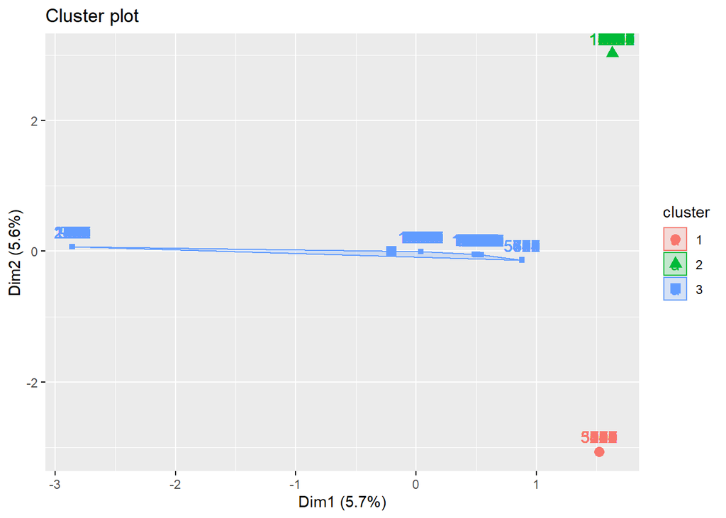

```r
fviz_cluster(kmeans_3, data = clinical_data_TCGA_bin_z)
```

I will try to improve.

### K-Means k=4

Try with k=4:

```r
set.seed(120)
kmeans_4 <- kmeans(clinical_data_TCGA_bin_z, 4, nstart=25)
str(kmeans_4)
```

```
## List of 9
##  $ cluster     : Named int [1:11512] 3 3 3 3 3 3 3 3 3 3 ...
##   ..- attr(*, "names")= chr [1:11512] "9861" "8791" "6564" "3070" ...
##  $ centers     : num [1:4, 1:19] -0.01318 -0.01318 0.00237 -0.01318 -0.04848 ...
##   ..- attr(*, "dimnames")=List of 2
##   .. ..$ : chr [1:4] "1" "2" "3" "4"
##   .. ..$ : chr [1:19] "tissue_or_organ_of_origin.Anterior.floor.of.mouth" "tissue_or_organ_of_origin.Anterior.mediastinum" "tissue_or_organ_of_origin.Anterior.wall.of.bladder" "tissue_or_organ_of_origin.Aortic.body.and.other.paraganglia" ...
##  $ totss       : num 218709
##  $ withinss    : num [1:4] 1.51e-24 7.77e-25 1.84e+05 2.94e-25
##  $ tot.withinss: num 183869
##  $ betweenss   : num 34840
##  $ size        : int [1:4] 650 669 9755 438
##  $ iter        : int 1
##  $ ifault      : int 0
##  - attr(*, "class")= chr "kmeans"
```

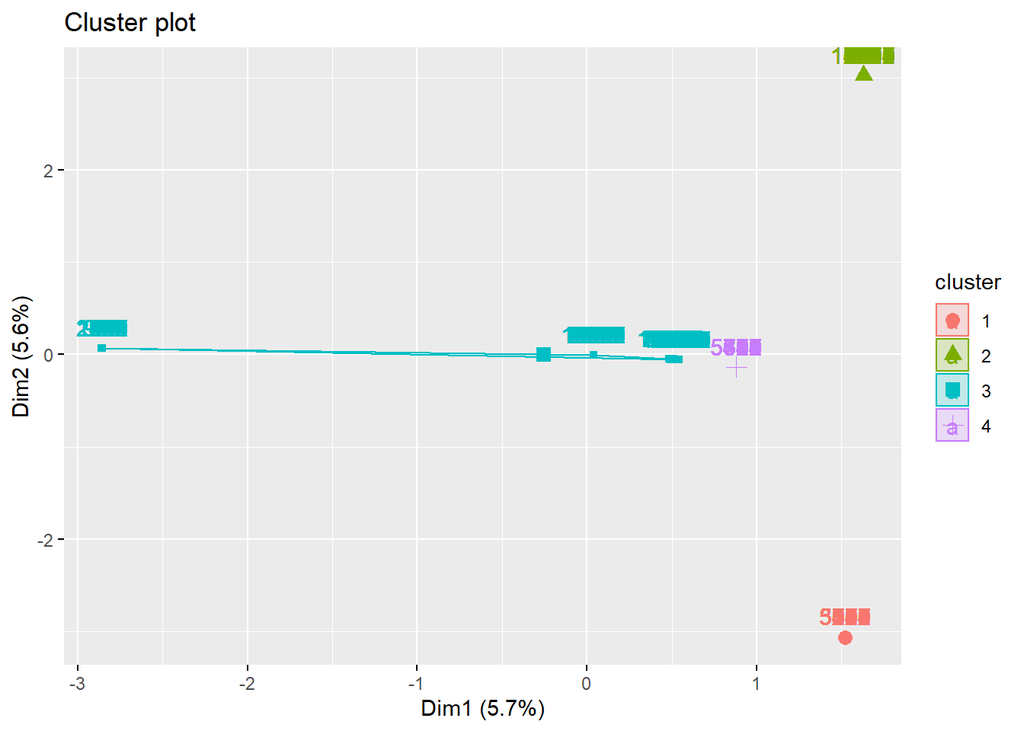

```r
fviz_cluster(kmeans_4, data = clinical_data_TCGA_bin_z)
```

There are clusters which is not bad, i will try with a higher k.

### K-Means k=5

Try with k=5:

```r
kmeans_5 <- kmeans(clinical_data_TCGA_bin_z, 5, nstart=25)
str(kmeans_5)
```

```
## List of 9
##  $ cluster     : Named int [1:11512] 2 2 2 2 2 2 2 2 2 4 ...
##   ..- attr(*, "names")= chr [1:11512] "9861" "8791" "6564" "3070" ...
##  $ centers     : num [1:5, 1:19] -0.0132 0.0015 -0.0132 -0.0132 -0.0132 ...
##   ..- attr(*, "dimnames")=List of 2
##   .. ..$ : chr [1:5] "1" "2" "3" "4" ...
##   .. ..$ : chr [1:19] "tissue_or_organ_of_origin.Anterior.floor.of.mouth" "tissue_or_organ_of_origin.Anterior.mediastinum" "tissue_or_organ_of_origin.Anterior.wall.of.bladder" "tissue_or_organ_of_origin.Aortic.body.and.other.paraganglia" ...
##  $ totss       : num 218709
##  $ withinss    : num [1:5] 0.00 1.72e+05 2.94e-25 2.75e-26 1.51e-24
##  $ tot.withinss: num 172400
##  $ betweenss   : num 46309
##  $ size        : int [1:5] 1 10336 438 87 650
##  $ iter        : int 1
##  $ ifault      : int 0
##  - attr(*, "class")= chr "kmeans"
```

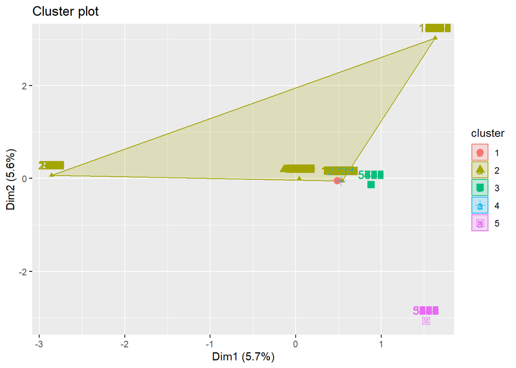

```r
fviz_cluster(kmeans_5, data = clinical_data_TCGA_bin_z)
```

There are more clusters - this supports the elbow method- the higher the better.